# Fidedignidade para testes congenéricos

Wagner de Lara Machado, PhD - PPG Psicologia PUCRS

17/05/2019

# Índices de fidedignidade para testes congenéricos

- [Existem limitações no uso do coeficiente **alpha de Cronbach** como estimativa de fidedignidade de testes psicológicos](https://www.ncbi.nlm.nih.gov/pmc/articles/PMC2792363/)
- A principal é que o **alpha de Cronbach** foi desenvolvido no contexto da Teoria Clássica dos Testes (TCT) e seu cálculo assume um pressuposto pouco realista, a **tau-equivalência**, isto é, que os testes ou itens possuam a mesma relação com o **escore verdadeiro**
- Para explicar esse conceito, é necessário retomar o modelo linear dos testes de **Spearman**:
  - *X* = *T* + *E*
  - Em que *X* é o escore observado em um teste ou item, *T* é o escore verdadeiro e *E* é o erro de medida
- Paralelismo, tau-equivalência e testes congenéricos
  - Para entender esses conceitos, vamos utilizar o diagrama representando o [Modelo linear de Spearman](https://en.wikipedia.org/wiki/Congeneric_reliability)

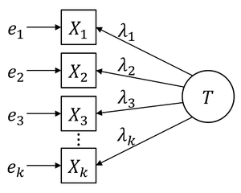

- Em que: *T* é o escore verdadeiro, *λ* a relação do teste/item com o escore verdadeiro (e.g. carga fatorial), *X* o teste ou item, e *e* o erro de medida.
  - Se Var(*e*) e *λ* são iguais para todos os testes ou itens, então tem-se testes/itens paralelos (paralelismo)
  - Se *λ* são iguais para todos os testes ou itens, então tem-se testes/itens tau-equivalentes
  - Se Var(*e*) e *λ* podem variar para todos os testes ou itens, então tem-se testes/itens congenéricos
- Esses pressupostos restritivos do **alpha de Cronbach** levaram o Editor da revista do European Journal of Psychological Assessment a incentivar o uso de medidas alternativas de fidedignidade em submissões, em [editorial publicado](https://econtent.hogrefe.com/doi/10.1027/1015-5759/a000069)
- Somando-se a esses argumentos, estudos indicam que índices alternativos possuem [performance superior](https://www.ncbi.nlm.nih.gov/pmc/articles/PMC4880791/) ao **alpha de Cronbach** sob condições realísticas, especialmente o **McDonald’s Omega** (**ω**)
- A seguir serão apresentadas formas de calcular o índice *McDonald’s Omega* (**ω**) com métodos confirmatórios e exploratórios:

## Carregando banco exemplo da [Escala de Satisfação com a Vida](https://www.researchgate.net/publication/279194945_Medindo_a_satisfacao_com_a_vida_dos_medicos_no_Brasil/download)

```
ESV<-read.csv("https://raw.githubusercontent.com/wagnerLM/SBP/master/ESV.csv",sep=";")

View(ESV)
```

### Para as análises, instale os seguintes pacotes

```
ininstall.packages("lavaan")
ininstall.packages("semTools")
ininstall.packages("psych")
```

## Com análise fatorial confirmatória

### Crie seu modelo com a sintaxe do lavaan

```
ESV.mod <- 'SV =~ ESV1 + ESV2 + ESV3 + ESV4 + ESV5'
```

### Ative o pacote

```
library(lavaan)
```

### Calcule o ajuste do modelo aos dados

```
fit.ESV.mod <- cfa(model = ESV.mod,data = ESV,ordered = colnames(ESV))
```

### Inspecione o ajuste do modelo

```
summary(fit.ESV.mod,fit.measures = TRUE, standardized=TRUE, rsq=TRUE)
```

### Calcule o McDonald’s **ω** com o pacote semTools

```
library(semTools)
reliability(fit.ESV.mod)
```

## Com análise exploratória

### Ative o pacote

```
library(psych)
```

### Conduza uma análise fatorial exploratória e avalie seu modelo

```
fa(ESV[1:5],1,cor="poly")
```

### Calcule o McDonald’s **ω**

```
omega(ESV[1:5],poly = T)
```

### Referências sobre os pacotes e fidedignidade

#### [psych](http://personality-project.org/r/html/guttman.html)

#### [lavaan](http://lavaan.ugent.be/)

#### [semTools](https://cran.r-project.org/web/packages/semTools/semTools.pdf)